# Treść Zadania

## Zadanie domowe - EDA Danych dotyczących Irysów

- Twoim zadaniem jest wykonanie analizy danych zawartych w załączonym pliku CSV (`25__iris.csv`).
- Plik znajduje się pod video. Pamiętaj, żeby wrzucić plik do tego samego folderu, w którym znajduje się ten notebook.
- Wykorzystaj nowo nabytą wiedzę z biblioteki `Pandas`
- Jeżeli jest taka konieczność posiłkuj się [code explainerem](https://codeexplainer.imprv.ai/) lub / i [data chatterem](https://datachatter.imprv.ai/) (który również te dane ma dostępne).
- Prześlij na discordzie notebook z rozwiązaniem (`#modul-4-zad1`)
- Pamiętaj:
1. Nie spiesz się
2. Potraktuj zadanie domowe jak prawdziwy projekt
3. Dodawaj opisy, obserwacje, wnioski
4. Dodaj wizualizacje
5. Dodaj konkluzję i wnioski końcowe

Powodzenia!!! I mega zabawy!

## O Danych

Zbiór danych zawiera informacje o trzech gatunkach irysów: Iris setosa, Iris versicolor, i Iris virginica.

Dane obejmują pomiary czterech cech: długość i szerokość działki kielicha oraz długość i szerokość płatka.

Każdy wiersz w zbiorze danych reprezentuje pojedynczy kwiat, a wartości pomiarów są podane w centymetrach.

Zbiór składa się z 150 próbek, po 50 dla każdego gatunku, i jest szeroko stosowany jako podstawowy zbiór danych do testowania algorytmów klasyfikacji oraz w nauce o danych i uczeniu maszynowym.

Kolumny:

- **długość kielicha (sepal length)** - Długość kielicha w cm
- **szerokość kielicha (sepal width)** - Szerokość kielicha w cm
- **długość płatka (petal length)** - Długość płatka w cm
- **szerokość płatka (petal width)** - Szerokość płatka w cm
- **klasa (class)** - Klasa irysa (setosa, versicolor, virginica)

# Inicjowanie danych

```python
import pandas as pd #wszyscy dają to ja też ;)
import seaborn as sns #albo grubo, albo wcale ;)
import matplotlib.pyplot as plt #aby rysować kilka wykresów na jednym "?płutnie?"
from matplotlib.ticker import MaxNLocator #bez tego nie zmienię rozdzielczości osi wykresu - a miałem taki kaprys ;)
from matplotlib.ticker import MultipleLocator #do ustawienia rozdzielczości osi w liczbach całkowitych
from matplotlib.colors import LinearSegmentedColormap #do utworzenia map kolorów dla każdego gatunku

#konfiguracja palety, zeby kolory były stałe dla gatunków na różnych wykresach
iris_palette = {
    "SETOSA": "#4C72B0",
    "VERSICOLOR": "#C44E52",
    "VIRGINICA": "#55A868"
}
#definicje kolorów gatunbków do ponownego uzycia w kodzie
color_set = "#4C72B0"
color_ver = "#C44E52"
color_vir = "#55A868"

#definicja map kolorów do heat-map
color_map_set = LinearSegmentedColormap.from_list("set",["white", color_set])
color_map_ver = LinearSegmentedColormap.from_list("ver",["white", color_ver])
color_map_vir = LinearSegmentedColormap.from_list("vir",["white", color_vir])

#konfigurator wykresów
def format_plot(thisplot, title, x_label=None, y_label=None, title_size=16, xlabel_size=10, ylabel_size=10, legend_title=None, setup_axis=True):
    thisplot.set_title(title, fontsize=title_size)
    if x_label is not None:
        thisplot.set_xlabel(x_label, fontsize=xlabel_size+2)
    if y_label is not None:
        thisplot.set_ylabel(y_label, fontsize=xlabel_size+2)
    if legend_title is not None:
        thisplot.get_legend().set_title(title=lagend_title)
    if setup_axis is True:
        thisplot.tick_params(axis='x', labelsize=xlabel_size)
        thisplot.tick_params(axis='y', labelsize=ylabel_size)
        thisplot.xaxis.set_major_locator(MultipleLocator(mlx_val))
        thisplot.yaxis.set_major_locator(MaxNLocator(integer=True))

#style do wyboru -> narzucenie stylu - legenda wyświetlała się z ciemnym tłem, pewnie przez narzucenie ciemnego stylu przez przeglądarkę
#sns.set_theme(style="whitegrid")
sns.set_theme(style="white")

df = pd.read_csv('25__iris.csv', sep=",")
df
```

|  | długość kielicha (sepal length) | szerokość kielicha (sepal width) | długość płatka (petal length) | szerokość płatka (petal width) | klasa (class) |
| --- | --- | --- | --- | --- | --- |
| 0 | 5.1 | 3.5 | 1.4 | 0.2 | Iris-setosa |
| 1 | 4.9 | 3.0 | 1.4 | 0.2 | Iris-setosa |
| 2 | 4.7 | 3.2 | 1.3 | 0.2 | Iris-setosa |
| 3 | 4.6 | 3.1 | 1.5 | 0.2 | Iris-setosa |
| 4 | 5.0 | 3.6 | 1.4 | 0.2 | Iris-setosa |
| ... | ... | ... | ... | ... | ... |
| 145 | 6.7 | 3.0 | 5.2 | 2.3 | Iris-virginica |
| 146 | 6.3 | 2.5 | 5.0 | 1.9 | Iris-virginica |
| 147 | 6.5 | 3.0 | 5.2 | 2.0 | Iris-virginica |
| 148 | 6.2 | 3.4 | 5.4 | 2.3 | Iris-virginica |
| 149 | 5.9 | 3.0 | 5.1 | 1.8 | Iris-virginica |

150 rows × 5 columns

# Zrozumienie przedmiotu badania

### IRIS SETOSA

### IRIS VERSICOLOR

### IRIS VIRGINICA

[figure not shown]

Kolor reprezentujący gatunek w pracy

[figure not shown]

Kolor reprezentujący gatunek w pracy

[figure not shown]

Kolor reprezentujący gatunek w pracy

# Przegląd danych

## 10 Losowych wierszy

```python
df.sample(10)
```

|  | długość kielicha (sepal length) | szerokość kielicha (sepal width) | długość płatka (petal length) | szerokość płatka (petal width) | klasa (class) |
| --- | --- | --- | --- | --- | --- |
| 47 | 4.6 | 3.2 | 1.4 | 0.2 | Iris-setosa |
| 134 | 6.1 | 2.6 | 5.6 | 1.4 | Iris-virginica |
| 16 | 5.4 | 3.9 | 1.3 | 0.4 | Iris-setosa |
| 87 | 6.3 | 2.3 | 4.4 | 1.3 | Iris-versicolor |
| 26 | 5.0 | 3.4 | 1.6 | 0.4 | Iris-setosa |
| 146 | 6.3 | 2.5 | 5.0 | 1.9 | Iris-virginica |
| 66 | 5.6 | 3.0 | 4.5 | 1.5 | Iris-versicolor |
| 31 | 5.4 | 3.4 | 1.5 | 0.4 | Iris-setosa |
| 51 | 6.4 | 3.2 | 4.5 | 1.5 | Iris-versicolor |
| 94 | 5.6 | 2.7 | 4.2 | 1.3 | Iris-versicolor |

## Informacje o kolumnach

```python
df.info()
```

```
<class 'pandas.core.frame.DataFrame'>
RangeIndex: 150 entries, 0 to 149
Data columns (total 5 columns):
 #   Column                            Non-Null Count  Dtype
---  ------                            --------------  -----
 0   długość kielicha (sepal length)   150 non-null    float64
 1   szerokość kielicha (sepal width)  150 non-null    float64
 2   długość płatka (petal length)     150 non-null    float64
 3   szerokość płatka (petal width)    150 non-null    float64
 4   klasa (class)                     150 non-null    object
dtypes: float64(4), object(1)
memory usage: 6.0+ KB
```

### Obserwacje:

- **brak pustych wartości**,
- dane liczbowe - sformatowane jako zmiennoprzecinkowe,
- 150 rekordów.

## Sprawdzenie czy dane są zgodne z opisem zadania

- po 50 rekordów z każdego rodzaju
- sensowność danych - np. czy wielkość płatków nie jest zbyt mała, lub duża

```python
df.describe().transpose()
```

|  | count | mean | std | min | 25% | 50% | 75% | max |
| --- | --- | --- | --- | --- | --- | --- | --- | --- |
| długość kielicha (sepal length) | 150.0 | 5.843333 | 0.828066 | 4.3 | 5.1 | 5.80 | 6.4 | 7.9 |
| szerokość kielicha (sepal width) | 150.0 | 3.054000 | 0.433594 | 2.0 | 2.8 | 3.00 | 3.3 | 4.4 |
| długość płatka (petal length) | 150.0 | 3.758667 | 1.764420 | 1.0 | 1.6 | 4.35 | 5.1 | 6.9 |
| szerokość płatka (petal width) | 150.0 | 1.198667 | 0.763161 | 0.1 | 0.3 | 1.30 | 1.8 | 2.5 |

## Sprawdzenie danych po klasach

```python
df.groupby("klasa (class)").describe().transpose()
```

|  | klasa (class) | Iris-setosa | Iris-versicolor | Iris-virginica |
| --- | --- | --- | --- | --- |
| długość kielicha (sepal length) | count | 50.000000 | 50.000000 | 50.000000 |
|  | mean | 5.006000 | 5.936000 | 6.588000 |
|  | std | 0.352490 | 0.516171 | 0.635880 |
|  | min | 4.300000 | 4.900000 | 4.900000 |
|  | 25% | 4.800000 | 5.600000 | 6.225000 |
|  | 50% | 5.000000 | 5.900000 | 6.500000 |
|  | 75% | 5.200000 | 6.300000 | 6.900000 |
|  | max | 5.800000 | 7.000000 | 7.900000 |
| szerokość kielicha (sepal width) | count | 50.000000 | 50.000000 | 50.000000 |
|  | mean | 3.418000 | 2.770000 | 2.974000 |
|  | std | 0.381024 | 0.313798 | 0.322497 |
|  | min | 2.300000 | 2.000000 | 2.200000 |
|  | 25% | 3.125000 | 2.525000 | 2.800000 |
|  | 50% | 3.400000 | 2.800000 | 3.000000 |
|  | 75% | 3.675000 | 3.000000 | 3.175000 |
|  | max | 4.400000 | 3.400000 | 3.800000 |
| długość płatka (petal length) | count | 50.000000 | 50.000000 | 50.000000 |
|  | mean | 1.464000 | 4.260000 | 5.552000 |
|  | std | 0.173511 | 0.469911 | 0.551895 |
|  | min | 1.000000 | 3.000000 | 4.500000 |
|  | 25% | 1.400000 | 4.000000 | 5.100000 |
|  | 50% | 1.500000 | 4.350000 | 5.550000 |
|  | 75% | 1.575000 | 4.600000 | 5.875000 |
|  | max | 1.900000 | 5.100000 | 6.900000 |
| szerokość płatka (petal width) | count | 50.000000 | 50.000000 | 50.000000 |
|  | mean | 0.244000 | 1.326000 | 2.026000 |
|  | std | 0.107210 | 0.197753 | 0.274650 |
|  | min | 0.100000 | 1.000000 | 1.400000 |
|  | 25% | 0.200000 | 1.200000 | 1.800000 |
|  | 50% | 0.200000 | 1.300000 | 2.000000 |
|  | 75% | 0.300000 | 1.500000 | 2.300000 |
|  | max | 0.600000 | 1.800000 | 2.500000 |

### Obserwacja:

- Różnica w medianach długości i szerokości kielichów pomiędzy gatunkami nie wydają się aż tak duże jak ma to miejsce w przypadku długości i szerokości płatków,
- Wartość minimalna i pierwszy kwartyl dla szerokości płatka IRIS-SETOSA wskazuje, że należy spodziewać się niskich wartości dla tego gatunku.

## Sprawdzamy ilość tak małych wartości dla szerokosci płatka

```python
df_sorted = df.sort_values(by=r"szerokość płatka (petal width)").reset_index(drop=True)
df_sorted.index += 1
df_sorted.head(25)
```

|  | długość kielicha (sepal length) | szerokość kielicha (sepal width) | długość płatka (petal length) | szerokość płatka (petal width) | klasa (class) |
| --- | --- | --- | --- | --- | --- |
| 1 | 5.2 | 4.1 | 1.5 | 0.1 | Iris-setosa |
| 2 | 4.3 | 3.0 | 1.1 | 0.1 | Iris-setosa |
| 3 | 4.9 | 3.1 | 1.5 | 0.1 | Iris-setosa |
| 4 | 4.9 | 3.1 | 1.5 | 0.1 | Iris-setosa |
| 5 | 4.8 | 3.0 | 1.4 | 0.1 | Iris-setosa |
| 6 | 4.9 | 3.1 | 1.5 | 0.1 | Iris-setosa |
| 7 | 5.1 | 3.5 | 1.4 | 0.2 | Iris-setosa |
| 8 | 5.2 | 3.5 | 1.5 | 0.2 | Iris-setosa |
| 9 | 5.2 | 3.4 | 1.4 | 0.2 | Iris-setosa |
| 10 | 4.7 | 3.2 | 1.6 | 0.2 | Iris-setosa |
| 11 | 4.8 | 3.1 | 1.6 | 0.2 | Iris-setosa |
| 12 | 5.5 | 4.2 | 1.4 | 0.2 | Iris-setosa |
| 13 | 5.5 | 3.5 | 1.3 | 0.2 | Iris-setosa |
| 14 | 4.4 | 3.0 | 1.3 | 0.2 | Iris-setosa |
| 15 | 5.1 | 3.4 | 1.5 | 0.2 | Iris-setosa |
| 16 | 4.4 | 3.2 | 1.3 | 0.2 | Iris-setosa |
| 17 | 5.1 | 3.8 | 1.6 | 0.2 | Iris-setosa |
| 18 | 4.6 | 3.2 | 1.4 | 0.2 | Iris-setosa |
| 19 | 5.3 | 3.7 | 1.5 | 0.2 | Iris-setosa |
| 20 | 5.0 | 3.3 | 1.4 | 0.2 | Iris-setosa |
| 21 | 5.0 | 3.0 | 1.6 | 0.2 | Iris-setosa |
| 22 | 4.8 | 3.4 | 1.9 | 0.2 | Iris-setosa |
| 23 | 5.0 | 3.2 | 1.2 | 0.2 | Iris-setosa |
| 24 | 4.6 | 3.1 | 1.5 | 0.2 | Iris-setosa |
| 25 | 4.7 | 3.2 | 1.3 | 0.2 | Iris-setosa |

### Obserwacja

# Transformacja danych

Zadanie rozwiązujemy w j. polskim więc przekształcimy dane dla ułatwienia sobie dalszej pracy

```python
df_pl = df.copy()
df_pl.columns = ["Długość kielicha", "Szerokość kielicha", "Długość płatka", "Szerokość płatka", "Gatunek"]
df_pl["Gatunek"] = df_pl["Gatunek"].str.upper()
df_pl["Gatunek"] = df_pl["Gatunek"].str.replace("IRIS-","",regex=False)
df_pl
```

|  | Długość kielicha | Szerokość kielicha | Długość płatka | Szerokość płatka | Gatunek |
| --- | --- | --- | --- | --- | --- |
| 0 | 5.1 | 3.5 | 1.4 | 0.2 | SETOSA |
| 1 | 4.9 | 3.0 | 1.4 | 0.2 | SETOSA |
| 2 | 4.7 | 3.2 | 1.3 | 0.2 | SETOSA |
| 3 | 4.6 | 3.1 | 1.5 | 0.2 | SETOSA |
| 4 | 5.0 | 3.6 | 1.4 | 0.2 | SETOSA |
| ... | ... | ... | ... | ... | ... |
| 145 | 6.7 | 3.0 | 5.2 | 2.3 | VIRGINICA |
| 146 | 6.3 | 2.5 | 5.0 | 1.9 | VIRGINICA |
| 147 | 6.5 | 3.0 | 5.2 | 2.0 | VIRGINICA |
| 148 | 6.2 | 3.4 | 5.4 | 2.3 | VIRGINICA |
| 149 | 5.9 | 3.0 | 5.1 | 1.8 | VIRGINICA |

150 rows × 5 columns

# Eksploracja kolumn

### Histogramy dla kolumn pogrupowane gatunkami kwiatów

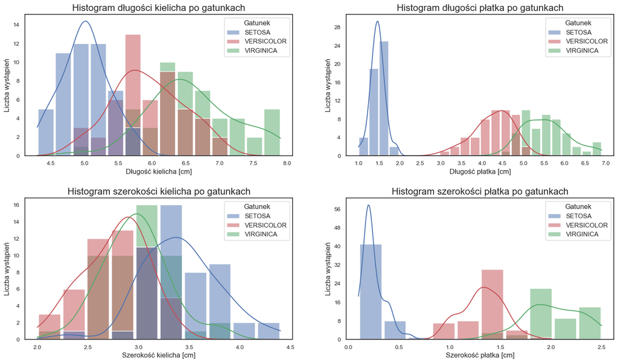

```python
fig, axes = plt.subplots(2, 2, figsize=(18,10)) #ustawia siatkę wykresów 2x2 o wielkości siatki 18x10 cali
plt.subplots_adjust(wspace = 0.2, hspace = 0.3)

mlx_val = 0.5 #rozdzielczość osi x
shrink_val = 0.9 #szerokość słupków (1 = 100%)
binwidth_val = 0.25 #szerokość zakresu jednego słupka histogramu
axis_label_size = 8

#Długość kielicha
thisplot = axes[0,0]
sns.histplot(ax=thisplot, data=df_pl, x="Długość kielicha", hue="Gatunek", kde=True, shrink=shrink_val, binwidth=binwidth_val, palette=iris_palette)
format_plot(thisplot, title="Histogram długości kielicha po gatunkach", x_label="Długość kielicha [cm]", y_label="Liczba wystąpień")

#Długość płatka
thisplot = axes[0,1]
sns.histplot(ax=thisplot, data=df_pl, x="Długość płatka", hue="Gatunek", kde=True, shrink=shrink_val, binwidth=binwidth_val, palette=iris_palette)
format_plot(thisplot, title="Histogram długości płatka po gatunkach", x_label="Długość płatka [cm]", y_label="Liczba wystąpień")

#Szerokość kielicha
thisplot = axes[1,0]
sns.histplot(ax=thisplot, data=df_pl, x="Szerokość kielicha", hue="Gatunek", kde=True, shrink=shrink_val, binwidth=binwidth_val, palette=iris_palette)
format_plot(thisplot, title="Histogram szerokości kielicha po gatunkach", x_label="Szerokość kielicha [cm]", y_label="Liczba wystąpień")

#Szerokość płatka
thisplot = axes[1,1]
sns.histplot(ax=thisplot, data=df_pl, x="Szerokość płatka", hue="Gatunek", kde=True, shrink=shrink_val, binwidth=binwidth_val, palette=iris_palette)
format_plot(thisplot, title="Histogram szerokości płatka po gatunkach", x_label="Szerokość płatka [cm]", y_label="Liczba wystąpień")
```

### Obserwacje

- Porównując szerokość i długość płatków możemy się spodziewać, że IRIS-SETOSA są najdrobniejszymi irysami, a IRIS-VIRGINICA najbardziej okazałymi.
- Można też zauważyć, że rozrzut w długości i szerokości płatków jest zdecydowanie mniejszy dla IRIS-SETOSA więc rozmiar płatków tego gatunku jest bardziej powtarzalny.
- Porównując kielichy możemy zauważyć, że szerokość kielicha jest podobna dla wszystkich gatunków, chociaż ciekawostką jest że najdrobniejsze IRIS-SETOSA mają najszersze kielichy. Jest to tym bardziej ciekawe, że w kwestii długości kielicha IRIS-SETOSA są najkrótsze.
- Porównanie czterech wykresów razem daje pewne wyobrażenie, że IRIS-SETOSA to drobne kwiaty o najszerszych, ale krótkich kielichach, z najdrobniejszymi listkami. Proporcje listków do kielichów tego gatunku mają inne proporcje niż dla gatunków IRIS-VERSICOLOR i IRIS-VIRGINICA. Te dwie odmiany mają podbne do siebie proporcje, natomiast IRIS-VIRGINICA mają zdecydowanie największe płatki.

# Relacje miedzy kolumnami

## Relacja szerokości i długości kielichów, oraz szerości i długości płatków

```python
#musimy trochę przerobić dane, zeby połączyć pogrupowac powtarzające sie elementy - to pozwli wyświetlać większe kropki na scatterplot dla wartości powtarzających się
grouped_df_kielich = df_pl.groupby(["Szerokość kielicha", "Długość kielicha", "Gatunek"]).size().reset_index(name="Liczba")
grouped_df_kielich.sort_values(by="Gatunek", inplace=True)#poprawka kolejności, zeby legenda wyswietlała się w takiej kolejnosci jak na innych wykresach

print(grouped_df_kielich)

grouped_df_płatki = df_pl.groupby(["Szerokość płatka", "Długość płatka", "Gatunek"]).size().reset_index(name="Liczba")
print(grouped_df_płatki)
```

```
     Szerokość kielicha  Długość kielicha    Gatunek  Liczba
125                 4.4               5.7     SETOSA       1
99                  3.4               4.8     SETOSA       2
98                  3.4               4.6     SETOSA       1
94                  3.3               5.1     SETOSA       1
52                  3.0               4.4     SETOSA       1
..                  ...               ...        ...     ...
68                  3.0               6.8  VIRGINICA       1
67                  3.0               6.7  VIRGINICA       1
96                  3.3               6.3  VIRGINICA       1
70                  3.0               7.2  VIRGINICA       1
88                  3.2               6.5  VIRGINICA       1

[126 rows x 4 columns]
     Szerokość płatka  Długość płatka    Gatunek  Liczba
0                 0.1             1.1     SETOSA       1
1                 0.1             1.4     SETOSA       1
2                 0.1             1.5     SETOSA       4
3                 0.2             1.0     SETOSA       1
4                 0.2             1.2     SETOSA       2
..                ...             ...        ...     ...
98                2.4             5.1  VIRGINICA       1
99                2.4             5.6  VIRGINICA       2
100               2.5             5.7  VIRGINICA       1
101               2.5             6.0  VIRGINICA       1
102               2.5             6.1  VIRGINICA       1

[103 rows x 4 columns]
```

```
(0.0, 2.62)
```

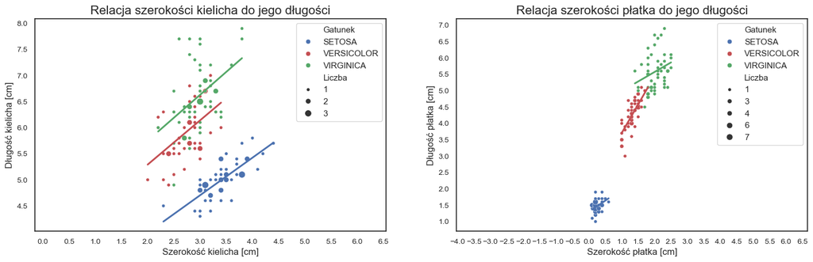

```python
fig, axes = plt.subplots(1, 2, figsize=(18,5))
plt.subplots_adjust(wspace = 0.2, hspace = 0.3)

thisplot = axes[0]
sns.scatterplot(ax=thisplot, data=grouped_df_kielich, x="Szerokość kielicha", y="Długość kielicha", hue="Gatunek", size="Liczba", palette=iris_palette)
#Linie trendu
sns.regplot(ax=thisplot, data=grouped_df_kielich[grouped_df_kielich["Gatunek"] == "SETOSA"], x="Szerokość kielicha", y="Długość kielicha", scatter=False, color=color_set, ci=None)
sns.regplot(ax=thisplot, data=grouped_df_kielich[grouped_df_kielich["Gatunek"] == "VERSICOLOR"], x="Szerokość kielicha", y="Długość kielicha", scatter=False, color=color_ver, ci=None)
sns.regplot(ax=thisplot, data=grouped_df_kielich[grouped_df_kielich["Gatunek"] == "VIRGINICA"], x="Szerokość kielicha", y="Długość kielicha", scatter=False, color=color_vir, ci=None)

format_plot(thisplot, title="Relacja szerokości kielicha do jego długości", x_label="Szerokość kielicha [cm]", y_label="Długość kielicha [cm]")
thisplot.set_aspect("equal", adjustable="datalim") #ustawienie równych proporcji między osiami, dla prawidłowego porównania danych w relacji
thisplot.xaxis.set_major_locator(MultipleLocator(0.5))
thisplot.yaxis.set_major_locator(MultipleLocator(0.5))

thisplot = axes[1]
sns.scatterplot(ax=thisplot, data=grouped_df_płatki, x="Szerokość płatka", y="Długość płatka", hue="Gatunek", size="Liczba", palette=iris_palette)
#Linie trendu
sns.regplot(ax=thisplot, data=grouped_df_płatki[grouped_df_płatki["Gatunek"] == "SETOSA"], x="Szerokość płatka", y="Długość płatka", scatter=False, color=color_set, ci=None)
sns.regplot(ax=thisplot, data=grouped_df_płatki[grouped_df_płatki["Gatunek"] == "VERSICOLOR"], x="Szerokość płatka", y="Długość płatka", scatter=False, color=color_ver, ci=None)
sns.regplot(ax=thisplot, data=grouped_df_płatki[grouped_df_płatki["Gatunek"] == "VIRGINICA"], x="Szerokość płatka", y="Długość płatka", scatter=False, color=color_vir, ci=None)

format_plot(thisplot, title="Relacja szerokości płatka do jego długości", x_label="Szerokość płatka [cm]", y_label="Długość płatka [cm]")
thisplot.set_aspect("equal", adjustable="datalim") #ustawienie równych proporcji między osiami, dla prawidłowego porównania danych w relacji
thisplot.xaxis.set_major_locator(MultipleLocator(0.5))
thisplot.yaxis.set_major_locator(MultipleLocator(0.5))
thisplot.set_xlim(left=0)
```

### Obserwacje

Dzięki zablokowaniu proporcji na osi x i y możemy dodatkowo wywnioskować:

#### Kielichy

Linie trendu nachylone są mniej wiecej pod kątem 45 stopni do osi x. Sugeruje to proporcjonalny wzrost długości kielicha przy wzroście jego szerokości. Duża odległość punktów od linii wskazuje jednak na niską korelacje między wartości i ich większą chaotyczność. O ile dla gatunku SETOSA obserwujemy punkty oddalone od linii trendu o wartości 0.5cm, to odległości od linii trendu dla pozostałych 2 gatunków sięgaja nawet ponad 1cm, co wskazuje na mniejsza korelację miedzy długościa a szerokością kielicha.

#### Płatki

Podobnie jak kielichy można zauważyć, że relacja długości płatka do szerokości płatka różni się w zależności od gatunku. Wygkląda na to, że silniejsza korelacja między szerokością a długością płatka jest tylko dla gatunku VERSICOLOR. Dla pozostałych gatunków wartości nie wygladaja na skorelowane, ze względu na dużą odległość od linii trendu w stosunku do rozrzutu danych.

#### Wniosek

Macież korelacji warto wykonać dla każdego gatunku osobno

## Macierz korelacji z podziałem po gatunkach

```python
#przygotowanie DF
cm_set=df_pl[df_pl["Gatunek"] == "SETOSA"].corr(numeric_only=True)
cm_ver=df_pl[df_pl["Gatunek"] == "VERSICOLOR"].corr(numeric_only=True)
cm_vir=df_pl[df_pl["Gatunek"] == "VIRGINICA"].corr(numeric_only=True)
```

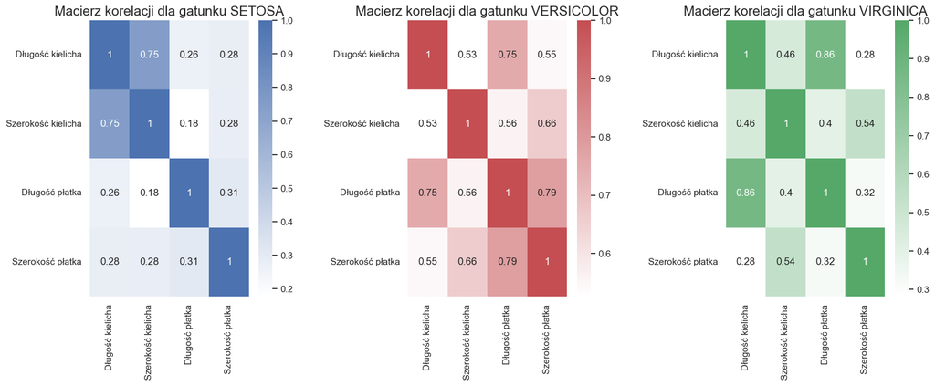

```python
fig, axes = plt.subplots(1, 3, figsize=(18,6))
plt.subplots_adjust(wspace = 0.6, hspace = 0.3)

thisplot = axes[0]
sns.heatmap(ax=thisplot, data=cm_set, annot=True, cmap=color_map_set)
format_plot(thisplot, title="Macierz korelacji dla gatunku SETOSA", setup_axis=False)

thisplot = axes[1]
sns.heatmap(ax=thisplot, data=cm_ver, annot=True, cmap=color_map_ver)
format_plot(thisplot, title="Macierz korelacji dla gatunku VERSICOLOR", setup_axis=False)

thisplot = axes[2]
sns.heatmap(ax=thisplot, data=cm_vir, annot=True, cmap=color_map_vir)
format_plot(thisplot, title="Macierz korelacji dla gatunku VIRGINICA", setup_axis=False)
```

### Obserwacje

- 3 osobne macierze korelacji potwierdzają rożne korelacje między cechami kwiatów w zależności od gatunku

#### IRIS SETOSA

- Macież korelacji potwierdza silną korelację między szerokoscią i długością kielicha, ale niską korelację między długością i szerokościa płatka. Oznacza to, że kwiaty w zbadanej populacji pomimo różnej wielkosci mają zbliżone proporcje kielichów z różnorodną szerokością i długością płatków.

#### IRIS VERSICOLOR

- W tej odmianie mamy mocno skorelowane dwie pary cech. okazuje się, że lepiej zachowane są proporcje płatków i długość płatka z długością kielicha. Cechy samego kielicha są srednio skorelowane. Podsumowując kwiaty tego gatunku pomimo dużej różnicy w wielkości pomiedzy osobnikami dobrze zachowują proporcje długości płatka z szerokością płatka i długości płatka z długością kielicha, mając różnorodne szerokości kielichów słabiej skorelowane z pozostałymi cechami.

#### IRIS VIRGINICA

# Rozkład danych i wartości odstające

```python
### Przygotowanie danych
df_melted = df_pl.melt(id_vars="Gatunek",value_vars=["Długość kielicha", "Szerokość kielicha", "Długość płatka", "Szerokość płatka"], var_name="Cechy", value_name="Wartość")

#DF SETOSA
m_set_df = df_melted[df_melted["Gatunek"] == "SETOSA"]
#DF VERSICOLOR
m_ver_df = df_melted[df_melted["Gatunek"] == "VERSICOLOR"]
#DF VIRGINICA
m_vir_df = df_melted[df_melted["Gatunek"] == "VIRGINICA"]
```

```
(0.0, 8.0)
```

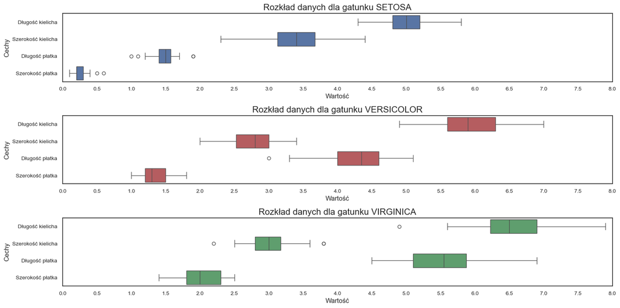

```python
fig, axes = plt.subplots(3, 1, figsize=(18,9))
plt.subplots_adjust(wspace = 0.6, hspace = 0.5)

thisplot = axes[0]
sns.boxplot(ax=thisplot, data=m_set_df, x="Wartość", y="Cechy", color=color_set)
format_plot(thisplot, title="Rozkład danych dla gatunku SETOSA")
thisplot.set_xlim(left=0, right=8)

thisplot = axes[1]
sns.boxplot(ax=thisplot, data=m_ver_df, x="Wartość", y="Cechy", color=color_ver)
format_plot(thisplot, title="Rozkład danych dla gatunku VERSICOLOR")
thisplot.set_xlim(left=0, right=8)

thisplot = axes[2]
sns.boxplot(ax=thisplot, data=m_vir_df, x="Wartość", y="Cechy", color=color_vir)
format_plot(thisplot, title="Rozkład danych dla gatunku VIRGINICA")
thisplot.set_xlim(left=0, right=8)
```

### Obserwacje

#### Wartości odstające

- Najwięcej wartości odstających obserwujemy w długości i szerokości płatków IRIS SETOSA. W gatunku VERSICOLOR w długości płatków, a w VIRGINICA w cechach kielicha.

### Porównanie rozkladów danych

- Pomimo dużych różnic w szerokości i długości płatków pomiędzy gatunkami szerokości kielichów są do siebie zbliżone.
- Wyraźnie obserwujemy jak IRIS SETOSA wyróżnia się największą szerokością kielicha, będąc najdrobniejszym kwiatem w stosunku do pozostałych gatunków.
- IRIS VIRGINICA ma największe płatki. Ich długość sięga nawet 7cm, a szerokość 2,5cm co jest znaczącą różnicą w stosunku do gatunku SETOSA, którego najdłuższe płatki mają niecałe 2cm.

# Wnioski końcowe i podsumowanie badanej populacji

### Cecha

### IRIS SETOSA

### IRIS VERSICOLOR

### IRIS VIRGINICA

Zdjęcie poglądowe

[figure not shown]

Kolor w pracy

Kolor reprezentujący gatunek w pracy

Kolor reprezentujący gatunek w pracy

Kolor reprezentujący gatunek w pracy

Opis ogólny

Kwiaty najdrobniejsze wśród badanych gatunków. Głównie ze względu na krótkie i wąskie płatki, gdyż rozmiary kielichów nie odstają znacząco od pozostałych gatunków. Szerokość kielichów dość mocno zróżnicowana w stosunku do pozostałych cech. W tym gatunku wystąpiły również najszersze kielichy pomimo tego, że płatki są zdecydowanie najdrobniejsze.

Kwiaty średniej wielkości w badanej populacji. Gatunek o najbardziej powtarzalnym wyglądzie płatków - silna korelacja między długością, a szerokoscią płatków, oraz długością kielicha.

Największe kwiaty z badanej populacji. Długość kielicha sięga prawie 8cm, a długość płatków niecałe 7cm. Te dwie cechy są też najmocniej skorelowane. Szerokości płatków i kielichów wykazują większe zróżnicowanie - nie zachowują proporcji w zalezności od wielkości.

Kielichy

Najszersze kielichy. Choć nie są najdłuższe, to wyróżniają się zdecydowanie szerokością w stosunku do płatków. Kielichy mają też powtarzalny kształt ze względu na silną korelacjię między długością, a szerokoscią.

Średniej wielkości kielichy. Długość i szerokość słabo skorelowana.

Najdłuższe kielichy. Ich szerokość nie jest mocno skorelowana z długością więc możemy liczyć na dużą różnorodność proporcji długości i szerokosci kielichów.

Płatki

Płatki średniej wielkości. Powtarzalny kształt - silna korelacja między szerokością, a długością.

# Brudnopis / notatki

## Testy wizualizacji histogramów

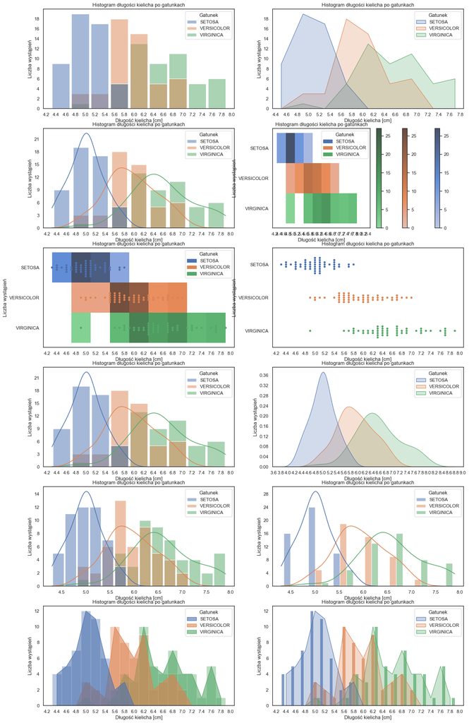

```python
fig, axes = plt.subplots(6, 2, figsize=(18,30)) #ustawia siatkę wykresów 2x2 o wielkości siatki 18x10 cali

#"lajfhak"
mlx_val = 0.2

#1
sns.histplot(ax=axes[0,0], data=df_pl, x="Długość kielicha", hue="Gatunek", shrink=0.9 )
axes[0,0].set_title("Histogram długości kielicha po gatunkach")
axes[0,0].set_xlabel("Długość kielicha [cm]")
axes[0,0].set_ylabel("Liczba wystąpień")
axes[0,0].get_legend().set_title(title="Gatunek")
axes[0,0].xaxis.set_major_locator(MultipleLocator(mlx_val)) #ustawienie kroku co 0.2
axes[0,0].yaxis.set_major_locator(MaxNLocator(integer=True))

#2
sns.histplot(ax=axes[0,1], data=df_pl, x="Długość kielicha", hue="Gatunek", element="poly", shrink=0.8 )
axes[0,1].set_title("Histogram długości kielicha po gatunkach")
axes[0,1].set_xlabel("Długość kielicha [cm]")
axes[0,1].set_ylabel("Liczba wystąpień")
axes[0,1].get_legend().set_title(title="Gatunek")
axes[0,1].xaxis.set_major_locator(MultipleLocator(mlx_val)) #ustawienie kroku co 0.2
axes[0,1].yaxis.set_major_locator(MaxNLocator(integer=True))

#3
thisplot = axes[1,0] #mały lajfhak ;)
sns.histplot(ax=thisplot, data=df_pl, x="Długość kielicha", hue="Gatunek", kde=True, shrink=0.8 )
thisplot.set_title("Histogram długości kielicha po gatunkach")
thisplot.set_xlabel("Długość kielicha [cm]")
thisplot.set_ylabel("Liczba wystąpień")
thisplot.get_legend().set_title(title="Gatunek")
thisplot.xaxis.set_major_locator(MultipleLocator(mlx_val)) #ustawienie kroku co 0.2
thisplot.yaxis.set_major_locator(MaxNLocator(integer=True))

#4
thisplot = axes[1,1] #mały lajfhak ;)
sns.histplot(ax=thisplot, data=df_pl, x="Długość kielicha", y="Gatunek", hue="Gatunek", kde=True, shrink=0.8, binwidth=0.4, cbar=True )
thisplot.set_title("Histogram długości kielicha po gatunkach")
thisplot.set_xlabel("Długość kielicha [cm]")
thisplot.set_ylabel("Liczba wystąpień")
thisplot.get_legend().set_title(title="Gatunek")
thisplot.xaxis.set_major_locator(MultipleLocator(mlx_val)) #ustawienie kroku co 0.2
thisplot.yaxis.set_major_locator(MaxNLocator(integer=True))

#5 w sumie przez błąd w kopiowaniu mi się zrobiło, ale szczęka mi opadła, że tak się da :D
thisplot = axes[2,0]
sns.swarmplot(ax=thisplot, data=df_pl, x="Długość kielicha", y="Gatunek", hue="Gatunek")
sns.histplot(ax=thisplot, data=df_pl, x="Długość kielicha", y="Gatunek", hue="Gatunek", kde=True, shrink=0.8 )
thisplot.set_title("Histogram długości kielicha po gatunkach")
thisplot.set_xlabel("Długość kielicha [cm]")
thisplot.set_ylabel("Liczba wystąpień")
thisplot.get_legend().set_title(title="Gatunek")
thisplot.xaxis.set_major_locator(MultipleLocator(mlx_val)) #ustawienie kroku co 0.2
thisplot.yaxis.set_major_locator(MaxNLocator(integer=True))

#6
thisplot = axes[2,1]
sns.swarmplot(ax=thisplot, data=df_pl, x="Długość kielicha", y="Gatunek", hue="Gatunek")
thisplot.set_title("Histogram długości kielicha po gatunkach")
thisplot.set_xlabel("Długość kielicha [cm]")
thisplot.set_ylabel("Liczba wystąpień")
#thisplot.get_legend().set_title(title="Gatunek") #nie działa z tym typem wykresu
thisplot.xaxis.set_major_locator(MultipleLocator(mlx_val)) #ustawienie kroku co 0.2
thisplot.yaxis.set_major_locator(MaxNLocator(integer=True))

#7
thisplot = axes[3,0] #mały lajfhak ;)
sns.histplot(ax=thisplot, data=df_pl, x="Długość kielicha", hue="Gatunek", kde=True, shrink=0.9, multiple="layer")
thisplot.set_title("Histogram długości kielicha po gatunkach")
thisplot.set_xlabel("Długość kielicha [cm]")
thisplot.set_ylabel("Liczba wystąpień")
thisplot.get_legend().set_title(title="Gatunek")
thisplot.xaxis.set_major_locator(MultipleLocator(mlx_val)) #ustawienie kroku co 0.2
thisplot.yaxis.set_major_locator(MaxNLocator(integer=True))

#8
thisplot = axes[3,1] #mały lajfhak ;)
sns.kdeplot(ax=thisplot, data=df_pl, x="Długość kielicha", hue="Gatunek", fill=True)
thisplot.set_title("Histogram długości kielicha po gatunkach")
thisplot.set_xlabel("Długość kielicha [cm]")
thisplot.set_ylabel("Liczba wystąpień")
thisplot.get_legend().set_title(title="Gatunek")
thisplot.xaxis.set_major_locator(MultipleLocator(mlx_val))
thisplot.yaxis.set_major_locator(MaxNLocator(integer=True))

#9
thisplot = axes[4,0] #mały lajfhak ;)
sns.histplot(ax=thisplot, data=df_pl, x="Długość kielicha", hue="Gatunek", kde=True, shrink=0.90, binwidth=0.25)
thisplot.set_title("Histogram długości kielicha po gatunkach")
thisplot.set_xlabel("Długość kielicha [cm]")
thisplot.set_ylabel("Liczba wystąpień")
thisplot.get_legend().set_title(title="Gatunek")
thisplot.xaxis.set_major_locator(MultipleLocator(0.5)) #ustawienie kroku co 0.2
thisplot.yaxis.set_major_locator(MaxNLocator(integer=True))

#10
thisplot = axes[4,1] #mały lajfhak ;)
sns.histplot(ax=thisplot, data=df_pl, x="Długość kielicha", hue="Gatunek", kde=True, shrink=0.8, binwidth=0.5, multiple="dodge")
thisplot.set_title("Histogram długości kielicha po gatunkach")
thisplot.set_xlabel("Długość kielicha [cm]")
thisplot.set_ylabel("Liczba wystąpień")
thisplot.get_legend().set_title(title="Gatunek")
thisplot.xaxis.set_major_locator(MultipleLocator(0.5)) #ustawienie kroku co 0.2
thisplot.yaxis.set_major_locator(MaxNLocator(integer=True))

#11
thisplot = axes[5,0]
sns.histplot(ax=thisplot, data=df_pl, x="Długość kielicha", hue="Gatunek", binwidth=0.2, alpha=0.4 )
sns.histplot(ax=thisplot, data=df_pl, x="Długość kielicha", hue="Gatunek", element="poly", binwidth=0.2, alpha=0.6)
thisplot.set_title("Histogram długości kielicha po gatunkach")
thisplot.set_xlabel("Długość kielicha [cm]")
thisplot.set_ylabel("Liczba wystąpień")
thisplot.get_legend().set_title(title="Gatunek")
thisplot.xaxis.set_major_locator(MultipleLocator(0.2)) #ustawienie kroku co 0.2
thisplot.yaxis.set_major_locator(MaxNLocator(integer=True))

#12
thisplot = axes[5,1]
sns.histplot(ax=thisplot, data=df_pl, x="Długość kielicha", hue="Gatunek", binwidth=0.2, alpha=0.7, multiple="dodge" )
sns.histplot(ax=thisplot, data=df_pl, x="Długość kielicha", hue="Gatunek", element="poly", binwidth=0.2, alpha=0.3)
thisplot.set_title("Histogram długości kielicha po gatunkach")
thisplot.set_xlabel("Długość kielicha [cm]")
thisplot.set_ylabel("Liczba wystąpień")
thisplot.get_legend().set_title(title="Gatunek")
thisplot.xaxis.set_major_locator(MultipleLocator(0.2)) #ustawienie kroku co 0.2
thisplot.yaxis.set_major_locator(MaxNLocator(integer=True))
```

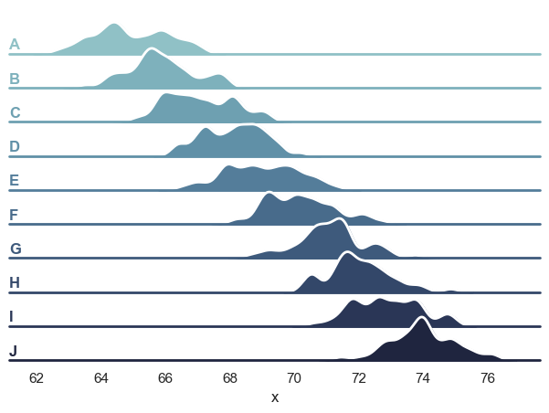

```python
import numpy as np
import pandas as pd
import seaborn as sns
import matplotlib.pyplot as plt
sns.set_theme(style="white", rc={"axes.facecolor": (0, 0, 0, 0)})

# Create the data
rs = np.random.RandomState(1979)
x = rs.randn(500)
g = np.tile(list("ABCDEFGHIJ"), 50)
df = pd.DataFrame(dict(x=x, g=g))
m = df.g.map(ord)
df["x"] += m

# Initialize the FacetGrid object
pal = sns.cubehelix_palette(10, rot=-.25, light=.7)
g = sns.FacetGrid(df, row="g", hue="g", aspect=15, height=.5, palette=pal)

# Draw the densities in a few steps
g.map(sns.kdeplot, "x",
      bw_adjust=.5, clip_on=False,
      fill=True, alpha=1, linewidth=1.5)
g.map(sns.kdeplot, "x", clip_on=False, color="w", lw=2, bw_adjust=.5)

# passing color=None to refline() uses the hue mapping
g.refline(y=0, linewidth=2, linestyle="-", color=None, clip_on=False)


# Define and use a simple function to label the plot in axes coordinates
def label(x, color, label):
    ax = plt.gca()
    ax.text(0, .2, label, fontweight="bold", color=color,
            ha="left", va="center", transform=ax.transAxes)


g.map(label, "x")

# Set the subplots to overlap
g.figure.subplots_adjust(hspace=-.25)

# Remove axes details that don't play well with overlap
g.set_titles("")
g.set(yticks=[], ylabel="")
g.despine(bottom=True, left=True)
```

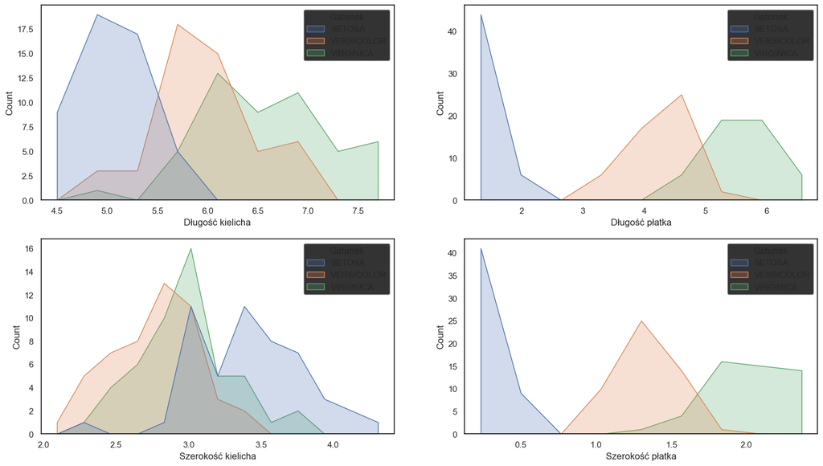

```python
fig, axes = plt.subplots(2, 2, figsize=(18,10)) #ustawia siatkę wykresów 2x2 o wielkości siatki 18x10 cali

#Długość kielicha
sns.histplot(ax=axes[0,0], data=df_pl, x="Długość kielicha", hue="Gatunek", element="poly")
#Długość płatka
sns.histplot(ax=axes[0,1], data=df_pl, x="Długość płatka", hue="Gatunek", element="poly")
sns.histplot(ax=axes[1,0], data=df_pl, x="Szerokość kielicha", hue="Gatunek", element="poly")
sns.histplot(ax=axes[1,1], data=df_pl, x="Szerokość płatka", hue="Gatunek", element="poly")
```

```python
#Przetworzenei danych do użycia w wykresie tak jak chcę ;)
df_melted = df_pl.melt(id_vars="Gatunek",value_vars=["Długość kielicha", "Szerokość kielicha", "Długość płatka", "Szerokość płatka"], var_name="Cechy", value_name="Wartość")
df_melted
```

|  | Gatunek | Cechy | Wartość |
| --- | --- | --- | --- |
| 0 | SETOSA | Długość kielicha | 5.1 |
| 1 | SETOSA | Długość kielicha | 4.9 |
| 2 | SETOSA | Długość kielicha | 4.7 |
| 3 | SETOSA | Długość kielicha | 4.6 |
| 4 | SETOSA | Długość kielicha | 5.0 |
| ... | ... | ... | ... |
| 595 | VIRGINICA | Szerokość płatka | 2.3 |
| 596 | VIRGINICA | Szerokość płatka | 1.9 |
| 597 | VIRGINICA | Szerokość płatka | 2.0 |
| 598 | VIRGINICA | Szerokość płatka | 2.3 |
| 599 | VIRGINICA | Szerokość płatka | 1.8 |

600 rows × 3 columns

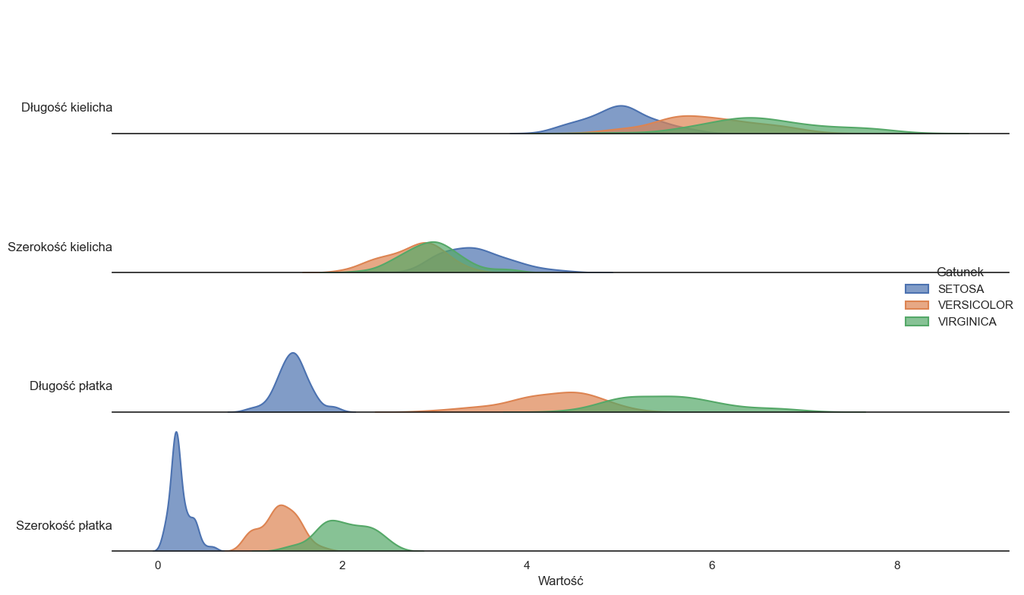

```python
#Facegrid z wierszami dla każdej cechy
g = sns.FacetGrid(df_melted, row="Cechy", hue="Gatunek", aspect=6, height=2, sharex=True)
g.map(sns.kdeplot, "Wartość", fill=True, alpha=0.7, linewidth=1.5)

#siatka i styl
g.set_titles("") #słabo to wygląda

g.set(yticks=[], ylabel="") #ukrycie wartości osi y i opisu osi y
g.despine(bottom=False, left=True)
g.fig.subplots_adjust(hspace=-0.9) #zmniejsza odległość między wykresami aby je nałożyć

#czary do wstawienia własnych etykiet
for ax, label in zip(g.axes.flat, ["Długość kielicha", "Szerokość kielicha", "Długość płatka", "Szerokość płatka"]):
    ax.text(0, 0.2, label, va="center", ha="right", rotation=0, fontsize=12, transform=ax.transAxes)

g.add_legend(title="Gatunek")
plt.tight_layout()
plt.show()
```

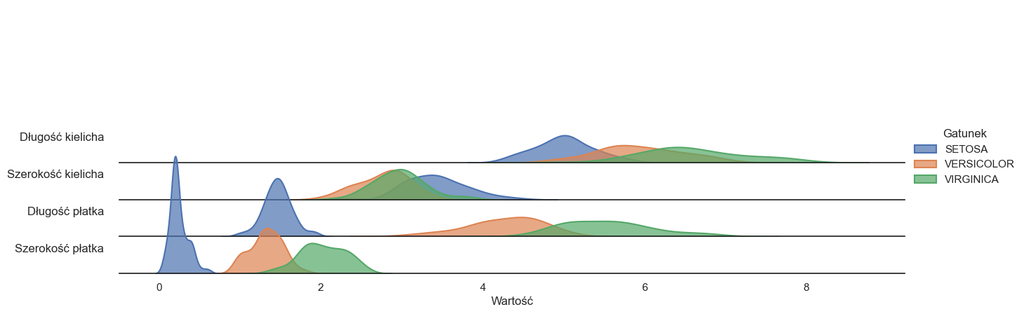

```python
#Facegrid z wierszami dla każdej cechy
g = sns.FacetGrid(df_melted, row="Cechy", hue="Gatunek", aspect=6, height=2, sharex=True)
g.map(sns.kdeplot, "Wartość", fill=True, alpha=0.7, linewidth=1.5)

#siatka i styl
g.set_titles("") #słabo to wygląda
g.set(yticks=[], ylabel="") #ukrycie wartości osi y i opisu osi y
g.despine(bottom=False, left=True)
g.fig.subplots_adjust(hspace=-0.7, top=0.5) #zmniejsza odległość między wykresami aby je nałożyć

#czary do wstawienia własnych etykiet
for ax, label in zip(g.axes.flat, ["Długość kielicha", "Szerokość kielicha", "Długość płatka", "Szerokość płatka"]):
    ax.text(-0.02, 0.2, label, va="center", ha="right", rotation=0, fontsize=12, transform=ax.transAxes)

g.add_legend(title="Gatunek")
plt.show()
```